# Statistical Inference Project

Mitch Murphy

4/17/2018

## Introduction

1. Simulate the exponential distribution
2. Calculate the mean and variability
3. Exploratory Data Analysis
   - Highlight basic features present in the data
4. Construct and interpret confidence intervals
5. What assumptions must hold?

## Simulation

Let us first sum up the exponential distribution: $\mu=\frac{1}{\lambda}$ and a variance $\sigma^2=\lambda^{-2}$.

```r
set.seed(round(1000*pi, 0))

lambda <- 0.2
# We willl be taking the average of 40 exponentials
n <- 40
# we will be comparing this distribution to 1000 random uniforms
numOfSims <- 1000
simulatedExponentials <- replicate(numOfSims, rexp(n, lambda))
# now lets compute the mean of these simulations
means <- apply(simulatedExponentials, 2, mean)
d <- density(means)
```

## Mean

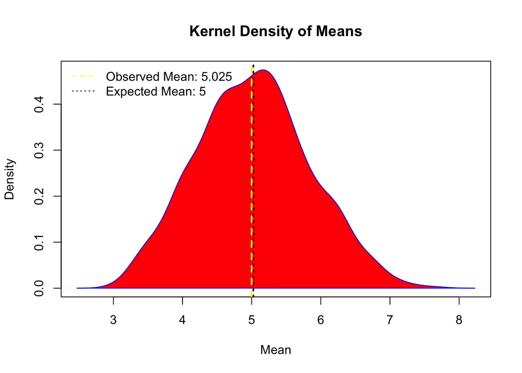

```r
plot(d, main = "Kernel Density of Means", xlab = "Mean")
polygon(d, col = "red", border = "blue")
observed_mean <- mean(means)
legend("topleft", legend = c(paste("Observed Mean:",round(observed_mean,3)), paste("Expected Mean:",lambda^-1)),
       lty = c(2,3), col = c("yellow", "black"), bty = "n")
abline(v=lambda^-1, col = "yellow", lwd = 2, lty = 2)
abline(v=observed_mean, col = "black", lty = 3, lwd = 2)
```

## Variability

In our case we must adjust $\sigma$ for the given sample size ($n=40$) so we have $\sigma^2=(\frac{1}{\lambda}\cdot\frac{1}{\sqrt{n}})^2$. Theoretically $\sigma^2=0.625$, however in this case $\sigma^2=0.6624831$

```r
# first let's compute the standard deviations
sample_sd <- sd(means)
expected_sd <- (1/lambda)/sqrt(n)
# now let's focus on the variance of the 2
sample_var <- sample_sd^2
expected_var <- ((1/lambda)*(1/sqrt(n)))^2
compareMatrix <- matrix(c(1/lambda,observed_mean,
                          expected_var, sample_var), nrow = 2)
rownames(compareMatrix) <- c("Expected","Observed")
colnames(compareMatrix) <- c("mean", "variance")
compareMatrix
```

```
##             mean  variance
## Expected 5.00000 0.6250000
## Observed 5.02503 0.6624831
```

## Normality

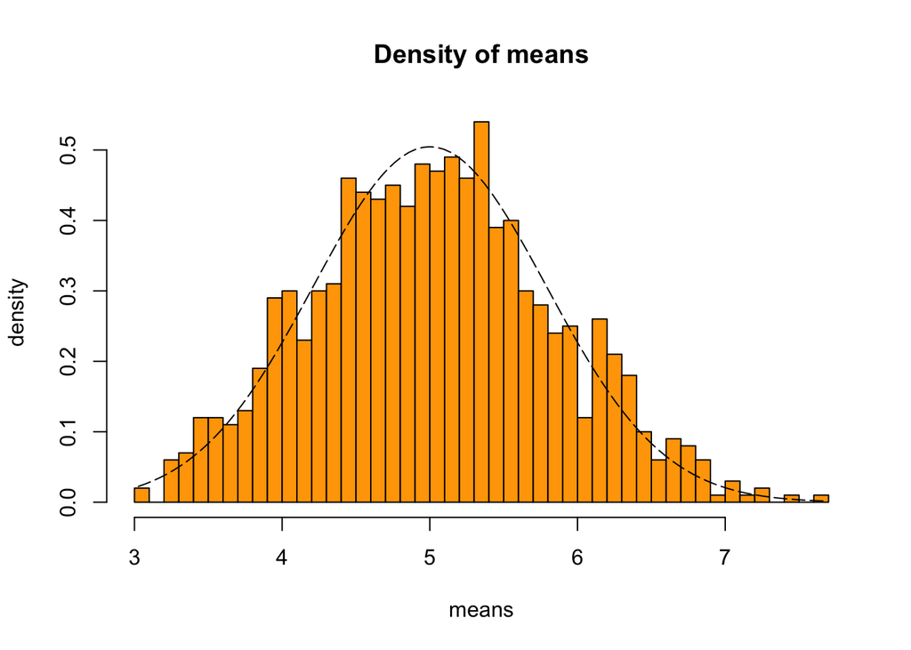

```r
# lets overlay the normal distribution over our observed data (density/histogram)
xfit <- seq(min(means), max(means), length=100)
yfit <- dnorm(xfit, mean=1/lambda, sd=(1/lambda/sqrt(n)))
hist(means,breaks=n,prob=T,col="orange",xlab = "means",main="Density of means",ylab="density")
lines(xfit, yfit, pch=22, col="black", lty=5)
```

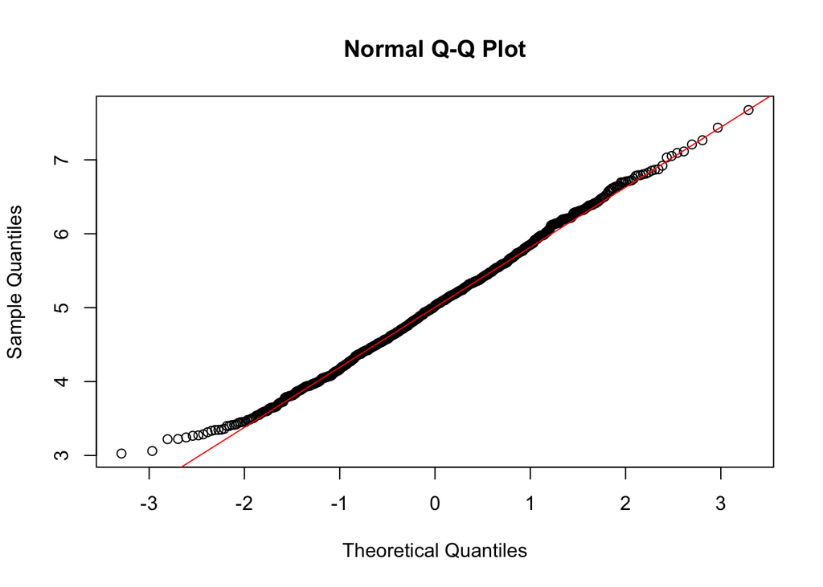

```r
qqnorm(means)
qqline(means, col = 2)
```

The distribution of the averages of 40 exponentials appears to be nearly identical to that of the normal distribution.

# Tooth Growth

## Summary of Data

Now let us take a look at the affect of two different supplements on tooth growth. First, let’s get an high-level overview of the data:

```r
tg <- ToothGrowth
tg$dose <- as.factor(tg$dose)
str(tg)
```

```
## 'data.frame':    60 obs. of  3 variables:
##  $ len : num  4.2 11.5 7.3 5.8 6.4 10 11.2 11.2 5.2 7 ...
##  $ supp: Factor w/ 2 levels "OJ","VC": 2 2 2 2 2 2 2 2 2 2 ...
##  $ dose: Factor w/ 3 levels "0.5","1","2": 1 1 1 1 1 1 1 1 1 1 ...
```

```r
summary(tg)
```

```
##       len        supp     dose
##  Min.   : 4.20   OJ:30   0.5:20
##  1st Qu.:13.07   VC:30   1  :20
##  Median :19.25           2  :20
##  Mean   :18.81
##  3rd Qu.:25.27
##  Max.   :33.90
```

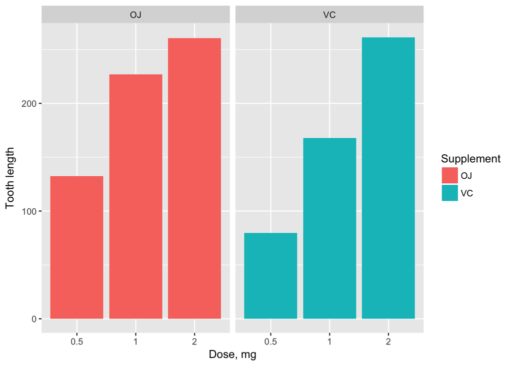

```r
ggplot(data=tg, aes(x=dose, y=len, fill=supp)) + geom_bar(stat="identity",) + facet_grid(. ~ supp) +
  xlab("Dose, mg") + ylab("Tooth length") + guides(fill=guide_legend(title="Supplement"))
```

## Confidence Intervals

Now let us construct 95% confidence intervals across the different doses.

```r
ci <- t.test(len ~ supp, data = tg)
pval <- ci$p.value
ci
```

```
##
##  Welch Two Sample t-test
##
## data:  len by supp
## t = 1.9153, df = 55.309, p-value = 0.06063
## alternative hypothesis: true difference in means is not equal to 0
## 95 percent confidence interval:
##  -0.1710156  7.5710156
## sample estimates:
## mean in group OJ mean in group VC
##         20.66333         16.96333
```

Since zero is contained in this interval, and because p-val$\geq \alpha=0.05$ we cannot reject the null hypothesis. Let’s further explore this data by creating dosage-groups, as so:

```r
tg.dose1 <- subset(tg, dose %in% c(0.5,1.0))
tg_dose2 <- subset(tg, dose %in% c(0.5,2.0))
tg_dose3 <- subset(tg, dose %in% c(1.0,2.0))

# construct the CI for dose of 0.5 and 1.0
t.test(len ~ dose, data = tg.dose1)
```

```
##
##  Welch Two Sample t-test
##
## data:  len by dose
## t = -6.4766, df = 37.986, p-value = 1.268e-07
## alternative hypothesis: true difference in means is not equal to 0
## 95 percent confidence interval:
##  -11.983781  -6.276219
## sample estimates:
## mean in group 0.5   mean in group 1
##            10.605            19.735
```

```r
#construct the CI for a dose of 0.5 and 2.0
t.test(len ~ dose, data = tg_dose2)
```

```
##
##  Welch Two Sample t-test
##
## data:  len by dose
## t = -11.799, df = 36.883, p-value = 4.398e-14
## alternative hypothesis: true difference in means is not equal to 0
## 95 percent confidence interval:
##  -18.15617 -12.83383
## sample estimates:
## mean in group 0.5   mean in group 2
##            10.605            26.100
```

```r
# construct the CI for a dose of 1.0 and 2.0
t.test(len ~ dose, data = tg_dose3)
```

```
##
##  Welch Two Sample t-test
##
## data:  len by dose
## t = -4.9005, df = 37.101, p-value = 1.906e-05
## alternative hypothesis: true difference in means is not equal to 0
## 95 percent confidence interval:
##  -8.996481 -3.733519
## sample estimates:
## mean in group 1 mean in group 2
##          19.735          26.100
```

Because zero is not contained in any of the above confidence intervals and the p-value $\leq \alpha$ we can conclude that the dose of the supplement effects tooth length; specifically as the dose increases so does the tooth length. We have already concluded that the supplement type is not significant (first CI above).

# Assumptions

When constructing confidence intervals (as we did above), we assumed that the variance of the 2 groups was different.